# Tarea 1

## Pregunta 3: Ley de los Grandes Numeros.

#### Frecuencia de Números Primos en un Dado

Se sabe que al lanzar un dado justo de 6 caras, hay tres resultados primos posibles: 2, 3 y 5. Por lo tanto, la probabilidad teórica de que salga un número primo en un lanzamiento es de $\frac{3}{6}=0.5$

Simule el experimento de lanzar un dado equilibrado 1000 veces y observe cómo evoluciona la frecuencia relativa de obtener un número primo a medida que aumenta el número de lanzamientos. Grafique el experimento para las secuencias de intentos que van desde 1 a 1000, señalando el valor en que converge la probabilidad de obtener un número primo.

Concluya desde que cantidad de lanzamientos podemos notar la convergencia hacia la probabilidad teórica

**Respuesta**

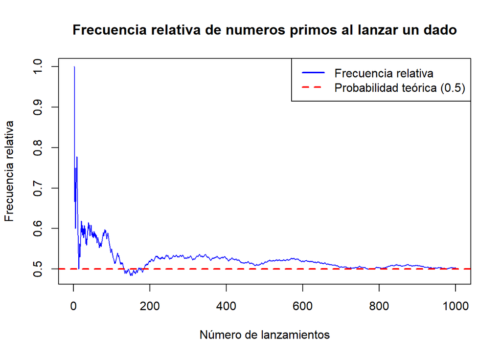

```r
# Inicializar lista vacía para ir guardando frecuencias
set.seed(27122021)
n_lanzamientos <- 1000
frecuencia_relativa <- c()

# Contador de primos
conteo_primos <- 0

# Resultados
caras <- 1:6
primos <- c(2, 3, 5)

# Simular lanzamientos uno a uno
for (i in 1:n_lanzamientos) {
  # Lanzar el dado (escogiendo un número aleatorio del vector de caras)
  lanzamiento <- sample(caras, 1, replace = TRUE)
  if (lanzamiento %in% primos) {
    conteo_primos <- conteo_primos + 1              # Si fue primo
  }
  frecuencia_relativa[i] <- conteo_primos / i       # Guardar frecuencia relativa acumulada
}

# Probabilidad teorica
p_teorica <- 0.5   # 3/6 = 0.5

# Grafico
plot(1:n_lanzamientos, frecuencia_relativa, type = "l", col = "blue",
     xlab = "Número de lanzamientos", ylab = "Frecuencia relativa",
     main = "Frecuencia relativa de numeros primos al lanzar un dado")
abline(h = p_teorica, col = "red", lty = 2, lwd = 2) # Línea teórica
legend("topright", legend = c("Frecuencia relativa", "Probabilidad teórica (0.5)"),
       col = c("blue", "red"), lty = c(1,2), lwd = 2)
```

La probabilidad teórica es 0.5, en particular desde los 200 lanzamientos ya se acerca a este valor, convergiendo desde arriba. En particular, desde aproximadamente los 700 lanzamientos se tiene que la frecuencia relativa ha logrado converger a la probabilidad teórica.

#### El problema de Monty Hall

Remontándonos en la televisión del año 1963, en USA existía un programa de concursos donde los participantes debían escoger entre 3 puertas para ganar un premio soñado. El problema del concurso era que solo detrás de 1 puerta estaba el premio mayor, mientras que detrás de las otras dos habían cabras como “premio”.

Una de las particularidades de este concurso, es que cuando el participante escogía una puerta, el animador del show abría una de las puertas que no fue escogida por el participante (Obviamente la puerta abierta por el animador no contenía el premio). Tras abrir la puerta, el animador consultaba al participante si su elección era definitiva, o si deseaba cambiar la puerta escogida por la otra puerta cerrada. Un vídeo que puede ayudar a comprender mejor este problema en el siguiente [link](https://www.youtube.com/watch?v=rSa_uiKncEI).

Imagine que usted es participante del concurso y desea calcular la probabilidad de ganar el gran premio **si cambia de puerta** en el momento que el animador se lo ofrece. Utilizando listas/arrays/vectores simule las puertas del concurso, dejando aleatoriamente el premio en alguna posición del array. Hecho esto, genere un numero de forma aleatoria para escoger una de las puerta (posiciones de la estructura), para luego ver si cambiando de posición tendrá mayores posibilidades de ganar el premio. Genere N veces el experimento y grafique cada una de las iteraciones, tal como se hizo en el ejercicio de las monedas.

[figure not shown]

**Respuesta:**

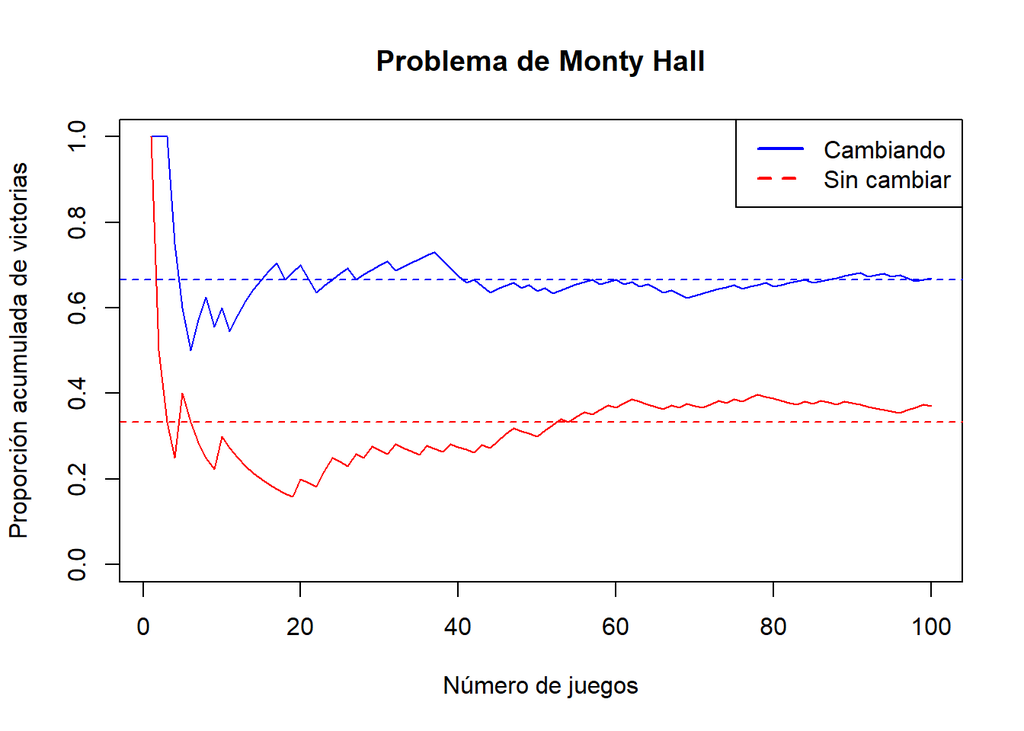

```r
# Creamos una función que simula el juego
# Args:
#   cambiar: Indica si el jugador cambia o no su elección luego de que el presentador abra una puerta

montyhall <- function(cambiar = TRUE){
  Puertas <- sample(1:3,3)                   # Puertas donde la posición que tiene el 3 es el premio
  puerta_premio <- which(Puertas == 3)       # Puerta de premio (indice para el array Puertas)
  puerta_jugador <- sample(1:3,1)            # Elección del participante. (indice para el array Puertas)

  #cat("Puertas:", Puertas, "\n")
  #cat("Puerta del premio (indice):", puerta_premio, "\n")
  #cat("Puerta del jugador (indice):", puerta_jugador, "\n\n")

  puertas_disponibles <- setdiff(1:3, c(puerta_premio, puerta_jugador))
  #cat("Puertas que se pueden abrir por el presentador (indices):", puertas_disponibles, "\n")

  # Si el vector puertas_disponibles es de una sola dimensión
  # entonces R genera un vector desde 1 hasta dicho numero
  # Ej: sample([2],1) => sample ([1,2],1)
  if(length(puertas_disponibles) == 1) {
    puerta_abierta <- puertas_disponibles[1]
  } else {
    puerta_abierta <- sample(puertas_disponibles, 1)
  }

  #cat("Puerta abierta por el presentador:", puerta_abierta, "\n")

  if(cambiar){
    puerta_jugador <- setdiff(1:3, c(puerta_jugador, puerta_abierta))
    #cat("Jugador cambia a la puerta:", puerta_jugador, "\n")
  }

  #cat("Gano o perdio", Puertas[puerta_jugador] == 3, "\n")
  #cat("------------------------\n")

  return(Puertas[puerta_jugador] == 3)
}

# Función para simular N juegos y calcular la proporción acumulada de victorias
# Args:
#   n: Cantidad de juegos a simular
#   cambiar_puerta: Indica si en la simulación, el jugador cambia de puerta o no

n_juegos <- function(n = 10, cambiar_puerta = TRUE){
  resultados <- replicate(n, montyhall(cambiar = cambiar_puerta))
  proporcion_acumulada <- cumsum(resultados) / (1:n)
  return(proporcion_acumulada)
}

set.seed(27122021)

# ------------------------------------------------ #
# Simulación: Ganar al cambiar de puerta
cambiar <- n_juegos(100, cambiar_puerta = TRUE)
# Simulación: Ganar al mantener la puerta
no_cambiar <- n_juegos(100, cambiar_puerta = FALSE)

# ------------------------------------------------ #
# Grafico
plot(cambiar, type = "l", col = "blue", ylim = c(0,1),
     xlab = "Número de juegos", ylab = "Proporción acumulada de victorias",
     main = "Problema de Monty Hall")
lines(no_cambiar, col = "red")
abline(h = 2/3, col = "blue", lty = 2) # Si el jugador cambia de eleccion debe converger a 2/3
abline(h = 1/3, col = "red", lty = 2)  # Si el jugador no cambia de elección debe converger a 1/3
legend("topright", legend = c("Cambiando", "Sin cambiar"),
       col = c("blue", "red"), lty = c(1,2), lwd = 2)
```

## Pregunta 4: ¿Independencia?

Se dispone de dos urnas, Urna1 y Urna2, cada una contiene bolas numeradas del 1 al 8, y cada bola es igualmente probable de ser extraída.

Definamos los eventos:

- Evento A: que la bola extraída de la **Urna1** sea un número par.
- Evento B: que la bola extraída de la **Urna2** sea un número menor o igual a 5.

Primero, calcule las probabilidades teóricas de cada evento. Luego, simule 1000 extracciones de bolas (una de cada urna) y grafique extracción a extracción $\mathbb{P}(A)$ y $\mathbb{P}(B)$,$P(A \cap B)$ y $P(A) \times P(B)$. Concluya si se evidencia que son independientes ($P(A \cap B) =\mathbb{P}(A)\mathbb{P}(B)$) .

Hecho lo anterior, considere un segundo experimento, en el cual solamente se extraiga bolas de la **Urna1** y se definen los siguientes eventos:

- Evento A: que la bola extraída es un número par.
- Evento B: que la bola extraída es menor o igual a 3.

Repita los pasos anteriores para estos nuevos Eventos. ¿Se observa independencia en este experimento?.

**Respuesta:**

```r
# Primer grupo de eventos
set.seed(27122021)
N_lan <- 1000  # Número de lanzamientos

# 1. Probabilidades teoricas

# bolas numeradas del 1 al 8
bolas <- 1:8

# Evento A: que la bola extraída de la **Urna1** sea un número par.
L_A = c(2, 4, 6, 8) # Lanzamientos favorables A = c(2, 4, 6, 8)
P_A_teorica <- length(L_A) / length(bolas)

# Evento B: que la bola extraída de la **Urna2** sea un número menor o igual a 5.
L_B = c(1, 2, 3, 4, 5) # Lanzamientos favorables B = c(1, 2, 3, 4, 5)
P_B_teorica <- length(L_B) / length(bolas)

# Evento A inter B: Urna1 par Y Urna2 <= 5
# Extracciones independientes => P(A inter B) = P(A) * P(B)
P_AB_teorica <- P_A_teorica * P_B_teorica

cat("Probabilidades teoricas:\n")
```

```
## Probabilidades teoricas:
```

```r
cat("P(A) = P(Urna1 par) =", P_A_teorica, "\n")
```

```
## P(A) = P(Urna1 par) = 0.5
```

```r
cat("P(B) = P(Urna2 <= 5) =", P_B_teorica, "\n")
```

```
## P(B) = P(Urna2 <= 5) = 0.625
```

```r
cat("P(A inter B) = P(A) * P(B) =", P_AB_teorica, "\n")
```

```
## P(A inter B) = P(A) * P(B) = 0.3125
```

```r
cat("P(A) * P(B) =", P_A_teorica * P_B_teorica, "\n\n")
```

```
## P(A) * P(B) = 0.3125
```

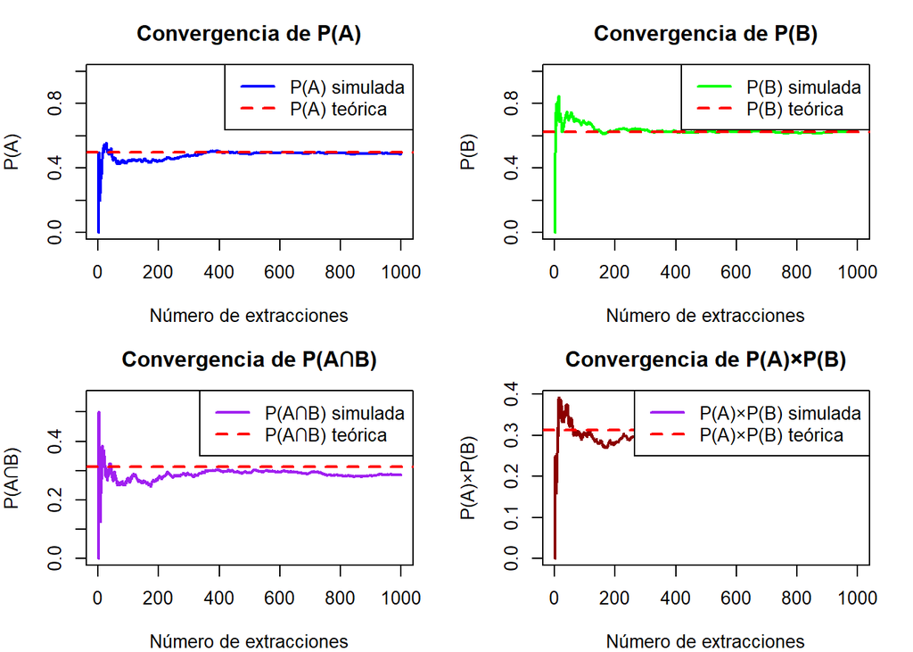

```r
# 2. Simulación

# Extracciones aleatorias
urna1_extracciones <- sample(1:8, N_lan, replace = TRUE)
urna2_extracciones <- sample(1:8, N_lan, replace = TRUE)

# Eventos
evento_A <- urna1_extracciones %% 2 == 0  # n par
evento_B <- urna2_extracciones <= 5       # n <= 5
evento_AB <- evento_A & evento_B          # se cumplen ambos

# Probabilidades acumuladas
P_A_sim <- cumsum(evento_A) / (1:N_lan)
P_B_sim <- cumsum(evento_B) / (1:N_lan)
P_AB_sim <- cumsum(evento_AB) / (1:N_lan)
P_A_x_P_B_sim <- P_A_sim * P_B_sim

# 3. Graficos
par(mfrow = c(2, 2), mar = c(4, 4, 3, 2))

# a. P(A)
plot(1:N_lan, P_A_sim, type = "l", col = "blue", lwd = 2,
     main = "Convergencia de P(A)",
     xlab = "Número de extracciones", ylab = "P(A)",
     ylim = c(0, 1))
abline(h = P_A_teorica, col = "red", lwd = 2, lty = 2)
legend("topright", c("P(A) simulada", "P(A) teórica"),
       col = c("blue", "red"), lwd = 2, lty = c(1, 2))

# b. P(B)
plot(1:N_lan, P_B_sim, type = "l", col = "green", lwd = 2,
     main = "Convergencia de P(B)",
     xlab = "Número de extracciones", ylab = "P(B)",
     ylim = c(0, 1))
abline(h = P_B_teorica, col = "red", lwd = 2, lty = 2)
legend("topright", c("P(B) simulada", "P(B) teórica"),
       col = c("green", "red"), lwd = 2, lty = c(1, 2))

# c. P(A inter B)
 plot(1:N_lan, P_AB_sim, type = "l", col = "purple", lwd = 2,
      main = "Convergencia de P(A∩B)",
      xlab = "Número de extracciones", ylab = "P(A∩B)",
      ylim = c(0, max(P_AB_sim) * 1.1))
 abline(h = P_AB_teorica, col = "red", lwd = 2, lty = 2)
 legend("topright", c("P(A∩B) simulada", "P(A∩B) teórica"),
        col = c("purple", "red"), lwd = 2, lty = c(1, 2))

# d. P(A) * P(B)
plot(1:N_lan, P_A_x_P_B_sim, type = "l", col = "darkred", lwd = 2,
     main = "Convergencia de P(A)×P(B)",
     xlab = "Número de extracciones", ylab = "P(A)×P(B)")
 abline(h = P_A_teorica * P_B_teorica, col = "red", lwd = 2, lty = 2)
 legend("topright", c("P(A)×P(B) simulada", "P(A)×P(B) teórica"),
        col = c("purple", "red"), lwd = 2, lty = c(1, 2))
```

```r
# e. Comparación entre P(A)X(B) y P(A inter B)
plot(1:N_lan, P_AB_sim, type = "l", col = "purple", lwd = 2,
     main = "Comparación de P(A∩B) vs P(A)×P(B)",
     xlab = "Número de extracciones", ylab = "Probabilidad",
     ylim = c(0, max(P_AB_sim, P_A_x_P_B_sim) * 1.1))
lines(1:N_lan, P_A_x_P_B_sim, col = "orange", lwd = 2)
legend("topright", c("P(A∩B) simulada", "P(A)×P(B) simulada"),
       col = c("purple", "orange", "red"), lwd = 2, lty = c(1, 1, 2))

# f. Diferencia entre P(X)XP(B) y P(A inter B)
diferencia <- abs(P_AB_sim - P_A_x_P_B_sim)
plot(1:N_lan, diferencia, type = "l", col = "darkred", lwd = 2,
     main = "Diferencia |P(A∩B) - P(A)×P(B)|",
     xlab = "Número de extracciones", ylab = "Diferencia")
abline(h = 0, col = "black", lty = 2)

# 3. Resultados para el último lanzamiento
cat("Probabilidades simuladas", "\n")
```

```
## Probabilidades simuladas
```

```r
cat("P(A) simulada =", round(P_A_sim[N_lan], 4), "\n")
```

```
## P(A) simulada = 0.488
```

```r
cat("P(B) simulada =", round(P_B_sim[N_lan], 4), "\n")
```

```
## P(B) simulada = 0.629
```

```r
cat("P(A inter B) simulada =", round(P_AB_sim[N_lan], 4), "\n")
```

```
## P(A inter B) simulada = 0.285
```

```r
cat("P(A) * P(B) simulada =", round(P_A_x_P_B_sim[N_lan], 4), "\n")
```

```
## P(A) * P(B) simulada = 0.307
```

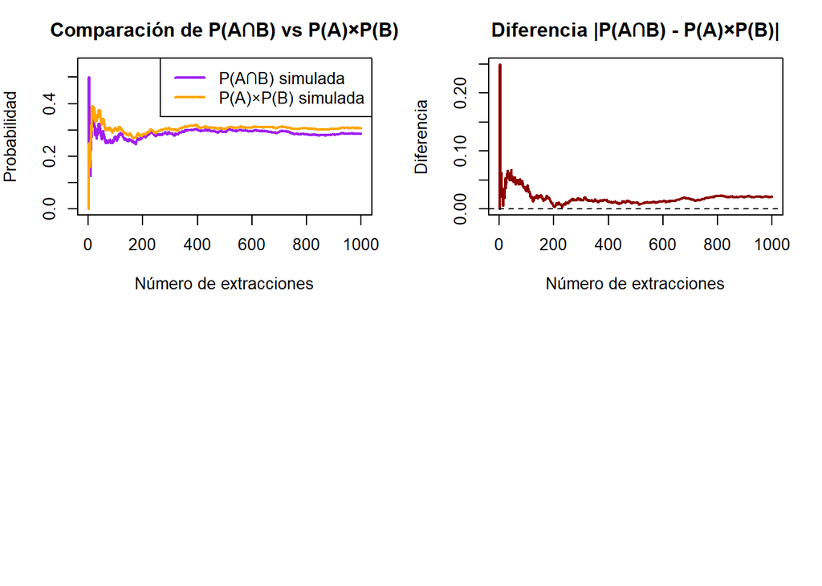

Para que dos eventos A y B sean independiente se debe cumplir que $P(A \cap B)=\mathbb{P}(A)\mathbb{P}(B)$. En particular, como trabajamos con números aleatorios, si $P(A \cap B)$ y $\mathbb{P}(A)\mathbb{P}(B)$ convergen al mismo valor, entonces se considera independiente. A partir del gráfico de la convergencia de la diferencia (último) se observa como esta tiende a 0, manteniendose muy por debajo de 0.05, y permitiendonos concluir que se cumple la independencia entre ambos eventos.

```r
# Segundo grupo de eventos
set.seed(27122021)
N_lan <- 1000  # Número de lanzamientos

# 1. Probabilidades teoricas

# bolas numeradas del 1 al 8
bolas <- 1:8

# Evento A: que la bola extraída sea un número par.
L_A = c(2, 4, 6, 8) # Lanzamientos favorables A = c(2, 4, 6, 8)
P_A_teorica <- length(L_A) / length(bolas)

# Evento B: que la bola extraida sea un número menor o igual a 3.
L_B = c(1, 2, 3) # Lanzamientos favorables B = c(1, 2, 3)
P_B_teorica <- length(L_B) / length(bolas)

# Evento A inter B: Numero de la bola es par y <= 3
L_AB <- intersect(L_A, L_B)
P_AB_teorica <- length(L_AB)/length(bolas)

cat("Probabilidades teoricas:\n")
```

```
## Probabilidades teoricas:
```

```r
cat("P(A) = P(bola par) =", P_A_teorica, "\n")
```

```
## P(A) = P(bola par) = 0.5
```

```r
cat("P(B) = P(bola <= 3) =", P_B_teorica, "\n")
```

```
## P(B) = P(bola <= 3) = 0.375
```

```r
cat("P(A inter B)", P_AB_teorica, "\n")
```

```
## P(A inter B) 0.125
```

```r
cat("P(A) * P(B) =", P_A_teorica * P_B_teorica, "\n\n")
```

```
## P(A) * P(B) = 0.1875
```

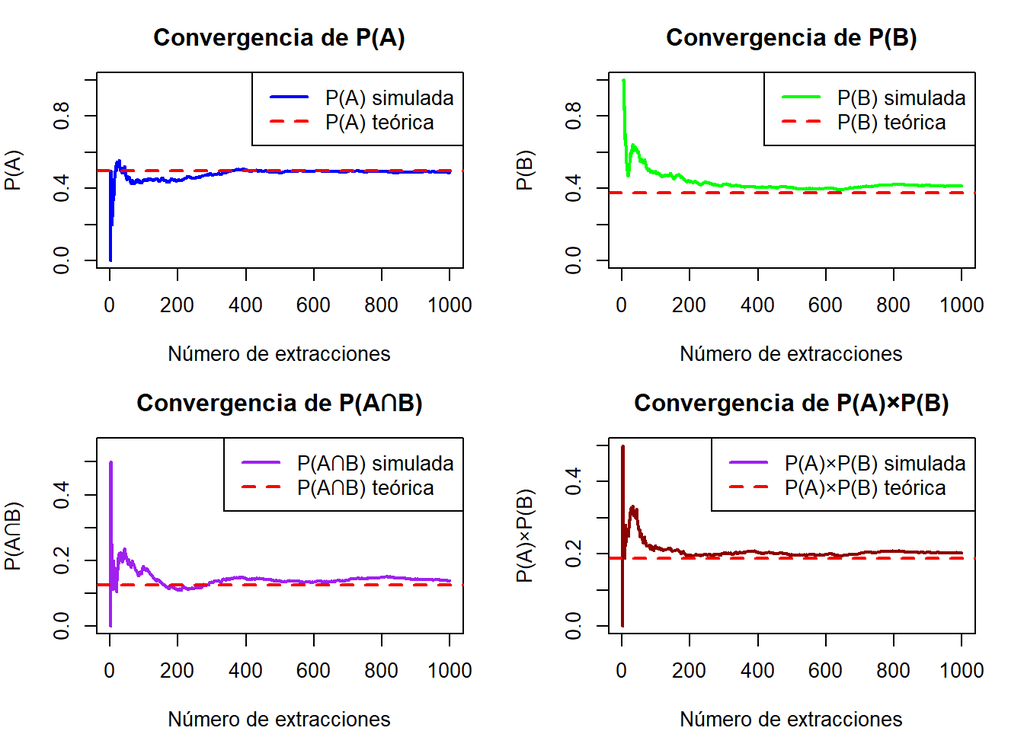

```r
# 2. Simulación

# Extracciones aleatorias
urna1_extracciones <- sample(1:8, N_lan, replace = TRUE)

# Eventos
evento_A <- urna1_extracciones %% 2 == 0  # La bola es par
evento_B <- urna1_extracciones <= 3       # La misma bola es <= 3
evento_AB <- evento_A & evento_B          # La misma bola cumple ambas


# Probabilidades acumuladas
P_A_sim <- cumsum(evento_A) / (1:N_lan)
P_B_sim <- cumsum(evento_B) / (1:N_lan)
P_AB_sim <- cumsum(evento_AB) / (1:N_lan)
P_A_x_P_B_sim <- P_A_sim * P_B_sim

# 3. Graficos
par(mfrow = c(2, 2), mar = c(4, 4, 3, 2))

# a. P(A)
plot(1:N_lan, P_A_sim, type = "l", col = "blue", lwd = 2,
     main = "Convergencia de P(A)",
     xlab = "Número de extracciones", ylab = "P(A)",
     ylim = c(0, 1))
abline(h = P_A_teorica, col = "red", lwd = 2, lty = 2)
legend("topright", c("P(A) simulada", "P(A) teórica"),
       col = c("blue", "red"), lwd = 2, lty = c(1, 2))

# b. P(B)
plot(1:N_lan, P_B_sim, type = "l", col = "green", lwd = 2,
     main = "Convergencia de P(B)",
     xlab = "Número de extracciones", ylab = "P(B)",
     ylim = c(0, 1))
abline(h = P_B_teorica, col = "red", lwd = 2, lty = 2)
legend("topright", c("P(B) simulada", "P(B) teórica"),
       col = c("green", "red"), lwd = 2, lty = c(1, 2))

# c. P(A inter B)
 plot(1:N_lan, P_AB_sim, type = "l", col = "purple", lwd = 2,
      main = "Convergencia de P(A∩B)",
      xlab = "Número de extracciones", ylab = "P(A∩B)",
      ylim = c(0, max(P_AB_sim) * 1.1))
 abline(h = P_AB_teorica, col = "red", lwd = 2, lty = 2)
 legend("topright", c("P(A∩B) simulada", "P(A∩B) teórica"),
        col = c("purple", "red"), lwd = 2, lty = c(1, 2))

# d. P(A) * P(B)
plot(1:N_lan, P_A_x_P_B_sim, type = "l", col = "darkred", lwd = 2,
     main = "Convergencia de P(A)×P(B)",
     xlab = "Número de extracciones", ylab = "P(A)×P(B)")
 abline(h = P_A_teorica * P_B_teorica, col = "red", lwd = 2, lty = 2)
 legend("topright", c("P(A)×P(B) simulada", "P(A)×P(B) teórica"),
        col = c("purple", "red"), lwd = 2, lty = c(1, 2))
```

```r
# e. Comparación entre P(A)X(B) y P(A inter B)
plot(1:N_lan, P_AB_sim, type = "l", col = "purple", lwd = 2,
     main = "Comparación de P(A∩B) vs P(A)×P(B)",
     xlab = "Número de extracciones", ylab = "Probabilidad",
     ylim = c(0, max(P_AB_sim, P_A_x_P_B_sim) * 1.1))
lines(1:N_lan, P_A_x_P_B_sim, col = "orange", lwd = 2)
legend("topright", c("P(A∩B) simulada", "P(A)×P(B) simulada"),
       col = c("purple", "orange", "red"), lwd = 2, lty = c(1, 1, 2))

# f. Diferencia entre P(X)XP(B) y P(A inter B)
diferencia <- abs(P_AB_sim - P_A_x_P_B_sim)
plot(1:N_lan, diferencia, type = "l", col = "darkred", lwd = 2,
     main = "Diferencia |P(A∩B) - P(A)×P(B)|",
     xlab = "Número de extracciones", ylab = "Diferencia")
abline(h = 0, col = "black", lty = 2)

# g. Resultados para el último lanzamiento
cat("Probabilidades simuladas", "\n")
```

```
## Probabilidades simuladas
```

```r
cat("P(A) simulada =", round(P_A_sim[N_lan], 4), "\n")
```

```
## P(A) simulada = 0.488
```

```r
cat("P(B) simulada =", round(P_B_sim[N_lan], 4), "\n")
```

```
## P(B) simulada = 0.414
```

```r
cat("P(A inter B) simulada =", round(P_AB_sim[N_lan], 4), "\n")
```

```
## P(A inter B) simulada = 0.139
```

```r
cat("P(A) * P(B) simulada =", round(P_A_x_P_B_sim[N_lan], 4), "\n")
```

```
## P(A) * P(B) simulada = 0.202
```

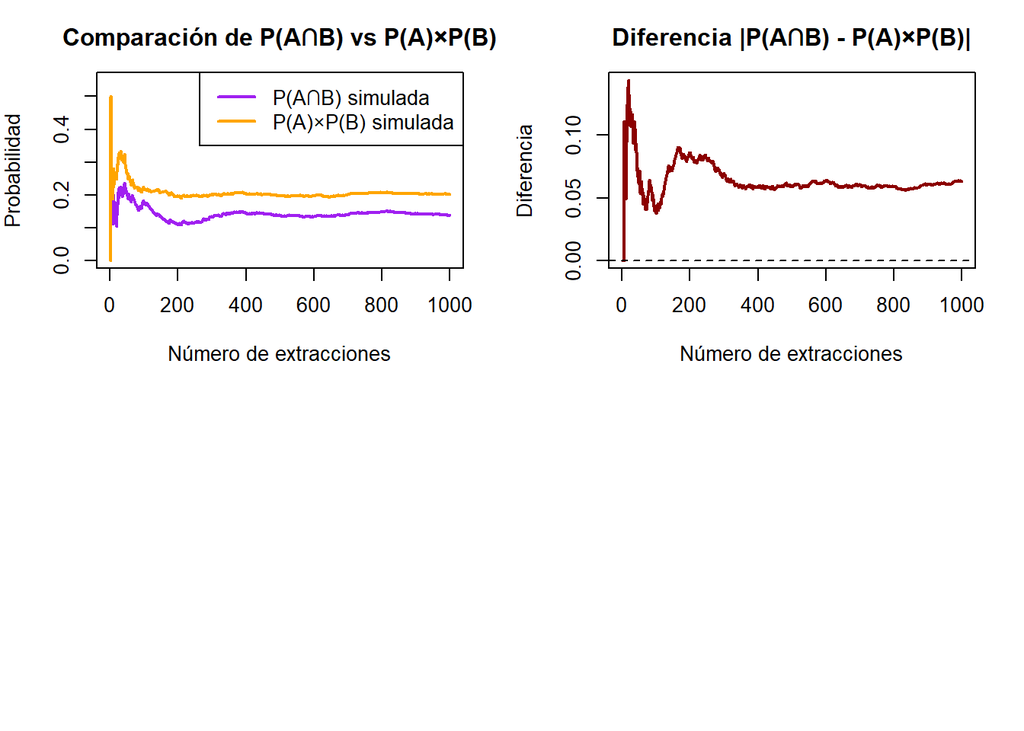

Para que dos eventos A y B sean independiente se debe cumplir que $P(A \cap B)=\mathbb{P}(A)\mathbb{P}(B)$. En particular, como trabajamos con números aleatorios, si $P(A \cap B)$ y $\mathbb{P}(A)\mathbb{P}(B)$ convergen al mismo valor, entonces se considera independiente. A partir del gráfico de la convergencia de la diferencia (último) se observa como esta no tiende a 0, manteniendose por sobre de 0.05, además que en el gráfico de comparación entre $P(A \cap B)$) y $\mathbb{P}(A)\mathbb{P}(B)$ vemos como ambas probabilidades tienen una clara diferencia. Esto nos permite concluir que se no cumple la independencia entre ambos eventos. Es decir, A y B son dependientes.

## Pregunta 5: Ruleta con estrategia de Martingala

La **estrategia de Martingala** es una famosa táctica de apuestas que se originó en Francia en el siglo XVIII y fue tradicionalmente utilizada en juegos de azar como la ruleta. La idea básica es sencilla: el jugador apuesta siempre a un evento con **probabilidad cercana a 0.5**, por ejemplo, apostar a rojo o negro en la ruleta. Cada vez que pierde, **dobla la apuesta** en la siguiente ronda. Cuando gana, recupera todas las pérdidas anteriores más una ganancia igual a la apuesta inicial, y entonces vuelve a apostar la cantidad inicial.

Un amigo le propone utilizar esta estrategia comenzando con un capital inicial de 200 dólares y una apuesta inicial fija, por ejemplo, de 5 dólares. En cada ronda, el jugador apuesta a un evento con probabilidad de ganar $p=\frac{18}{37} \approx 0.486$(la probabilidad de que salga rojo o negro en una ruleta europea). Si pierde la apuesta, en la siguiente ronda debe doblar el monto apostado; si gana, recupera todas las pérdidas acumuladas más la ganancia correspondiente a la apuesta inicial y vuelve a apostar la cantidad inicial. Además, si en algún momento el jugador no cuenta con fondos suficientes para cubrir la apuesta requerida, deberá apostar todo el dinero disponible en esa ronda. El jugador pierde cuando se queda sin fondos, y el juego termina cuando esto ocurre o cuando alcanza un capital objetivo de 300 dólares. Cabe destacar que al ganar una apuesta, el jugador recibe el doble del monto apostado. Por ejemplo, si tiene 200 dólares, apuesta 5 y gana, entonces su nuevo capital será 205 dólares.

En la primera parte del experimento, se debe simular y graficar la evolución del capital de 5 partidas bajo esta estrategia, observando las diferentes trayectorias posibles. Además, se debe calcular la probabilidad empírica de que el jugador alcance el capital objetivo de 300 dólares antes de quedarse sin fondos simulando 1000 partidas de esta estrategia.

Para la segunda parte del experimento, se comparará la estrategia de Martingala con una estrategia más simple donde el jugador apuesta constantemente 5 dólares en cada ronda, independientemente de ganar o perder, manteniendo la misma probabilidad de éxito $p=\frac{18}{37}$. En esta segunda estrategia, las condiciones de finalización del juego son las mismas: termina cuando el jugador se queda sin fondos o alcanza el capital objetivo. También se deben simular 5 partidas, graficar la evolución del capital y luego, simulando 1000 partidas (sin graficar estas) calcular la probabilidad de éxito bajo esta estrategia fija para compararla con la de Martingala.

*Hint: Para calcular realizar el cálculo de la probabilidad de éxito, en cada experimento, únicamente es necesario revisar el último valor del vector vec_fondos*

**Respuesta**

```r
# Función para obtener el desarrollo de las apuestas mediante Martingala
# Args:
#   fondos: Cantidad de dinero disponible
#   apuesta_inicial: monto inicial a apostar

Martingala <- function(fondos = 200, apuesta_inicial = 5){
  vector_fondos <- fondos # Evolución de los fondos
  apuesta_actual <- apuesta_inicial # Al inicio
  p <- 18/37 # Probabilidad de ganar fija

  # Mientras hayan fondos, o se llegue a la meta de 300 dls
  while (0<fondos && fondos<300) {
    # Si mi supuesta actual supera mis fondos, apuesto todo
    if (apuesta_actual > fondos){
      apuesta_actual <- fondos
    }

    # Ganar la apuesta
    if (runif(1)<=p){ # numero aleatorio entre 0 y 1 => p(ganar) = 18/37
      # Ganancia
      fondos <- fondos + apuesta_actual
      # Volver a apostar la cantidad inicial
      apuesta_actual <- apuesta_inicial
    } else { # Perder la apuesta
      fondos <- fondos - apuesta_actual
      # Doblar la apuesta actual
      apuesta_actual <- apuesta_actual * 2
    }

    vector_fondos <- c(vector_fondos, fondos)
  }
  return(vector_fondos) # Devuelve un vector con el desarrollo de los fondos
}
```

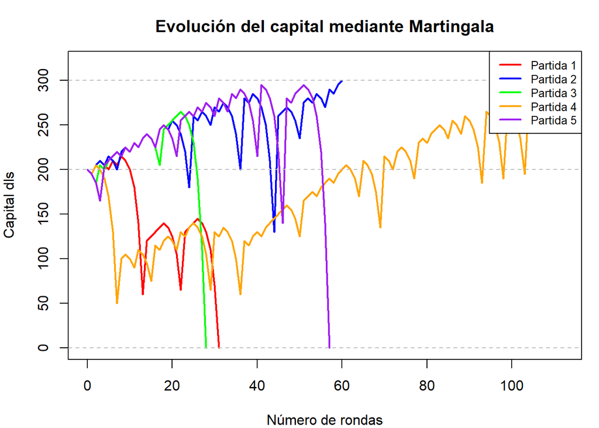

```r
# Simulacion de 5 partidas
set.seed(27122021)

# Almacernar resultados
partidas_martingala <- list()

for (i in 1:5) {
  partidas_martingala[[i]] <- Martingala()
}

# Grafico
par(mfrow = c(1, 1), mar = c(4, 4, 3, 1))
plot(0, 0, type = "n", xlim = c(0, max(sapply(partidas_martingala, length))),
     ylim = c(0, 320), xlab = "Número de rondas", ylab = "Capital dls",
     main = "Evolución del capital mediante Martingala")

colores <- c("red", "blue", "green", "orange", "purple")
for (i in 1:5) {
  lines(0:(length(partidas_martingala[[i]])-1), partidas_martingala[[i]], col = colores[i], lwd = 2)
}

# Lineas de referencia
abline(h = 200, col = "gray", lty = 2, lwd = 1)  # fondo inicial
abline(h = 300, col = "gray", lty = 2, lwd = 1)  # fondo objetivo
abline(h = 0, col = "gray", lty = 2, lwd = 1)    # Sin fondos

legend("topright", legend = paste("Partida", 1:5), col = colores, lwd = 2, cex = 0.8)
```

```r
for (i in 1:5) {
  capital_final <- tail(partidas_martingala[[i]], 1)
  resultado <- ifelse(capital_final >= 300, "Ganó", "Perdió")
  cat(sprintf("Partida %d: Capital final = $%d, Rondas = %d, %s\n", i, capital_final, length(partidas_martingala[[i]])-1, resultado))
}
```

```
## Partida 1: Capital final = $0, Rondas = 31, Perdió
## Partida 2: Capital final = $300, Rondas = 60, Ganó
## Partida 3: Capital final = $0, Rondas = 28, Perdió
## Partida 4: Capital final = $300, Rondas = 111, Ganó
## Partida 5: Capital final = $0, Rondas = 57, Perdió
```

```r
# Probabilidad empirica vía simulación de 1.000 partidas
set.seed(27122021)

# Cantidad de partidas ganadas
ganadas_martingala <- 0

for (i in 1:1000) {
  # La simulación de la partida devuelve un vector cuya ultima posición son los fondos finales
  resultado <- Martingala()
  if (tail(resultado, 1) >= 300) {
    ganadas_martingala <- ganadas_martingala + 1
  }
}

prob_ganar_martingala <- ganadas_martingala / 1000
cat(sprintf("\nProbabilidad de ganar usando Martingala: %.3f\n", prob_ganar_martingala))
```

```
##
## Probabilidad de ganar usando Martingala: 0.631
```

```r
# Función para obtener el desarrollo de las apuestas mediante el metodo tradicional
# Args:
#   fondos: Cantidad de dinero disponible
#   apuesta_inicial: monto inicial a apostar

ApuestaTradicional <- function(fondos = 200, apuesta = 5){
  vector_fondos <- fondos  # Evolucion de los fondos
  p <- 18/37 # Probabilidad de ganar fija
  while (fondos > 0 & fondos < 300) {
    # Ganar
    if (runif(1) <= p) {
      fondos <- fondos + apuesta
    } else {  # Perder
      fondos <- fondos - apuesta
    }

    vector_fondos <- c(vector_fondos, fondos)
  }


  return(vector_fondos)
}
```

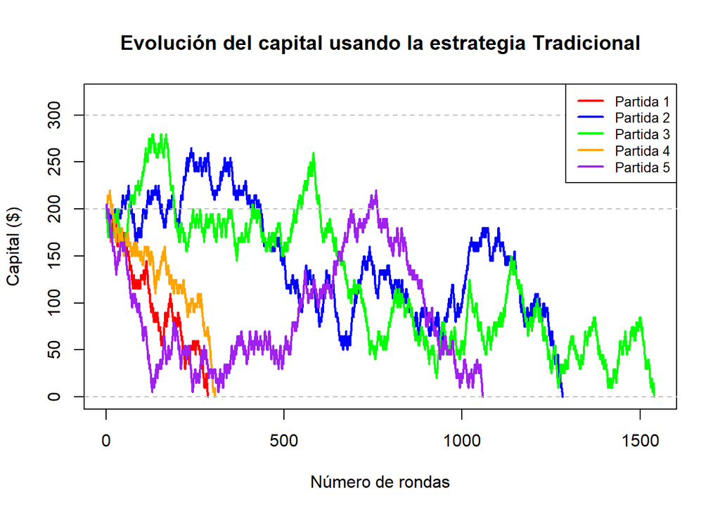

```r
# Grafico de 5 partidas
set.seed(27122021)

# Lista de resultados
partidas_tradicional <- list()

for (i in 1:5) {
  partidas_tradicional[[i]] <- ApuestaTradicional()
}

# Grafico
plot(0, 0, type = "n", xlim = c(0, max(sapply(partidas_tradicional, length))),
     ylim = c(0, 320), xlab = "Número de rondas", ylab = "Capital ($)",
     main = "Evolución del capital usando la estrategia Tradicional")

for (i in 1:5) {
  lines(0:(length(partidas_tradicional[[i]])-1), partidas_tradicional[[i]], col = colores[i], lwd = 2)
}

# Lineas de referencia
abline(h = 200, col = "gray", lty = 2, lwd = 1)  # fondo inicial
abline(h = 300, col = "gray", lty = 2, lwd = 1)  # fondo objetivo
abline(h = 0, col = "gray", lty = 2, lwd = 1)    # Sin fondos

legend("topright", legend = paste("Partida", 1:5), col = colores, lwd = 2, cex = 0.8)
```

```r
# Resultados
cat("\nResultados de las 5 partidas tradicionales:\n")
```

```
##
## Resultados de las 5 partidas tradicionales:
```

```r
for (i in 1:5) {
  capital_final <- tail(partidas_tradicional[[i]], 1)
  resultado <- ifelse(capital_final >= 300, "Ganó", "Perdió")
  cat(sprintf("Partida %d: Capital final = $%d, Rondas = %d, %s\n", i, capital_final, length(partidas_tradicional[[i]])-1, resultado))
}
```

```
## Partida 1: Capital final = $0, Rondas = 286, Perdió
## Partida 2: Capital final = $0, Rondas = 1282, Perdió
## Partida 3: Capital final = $0, Rondas = 1540, Perdió
## Partida 4: Capital final = $0, Rondas = 306, Perdió
## Partida 5: Capital final = $0, Rondas = 1058, Perdió
```

```r
# 1000 partidas
set.seed(27122021)

# Partidas ganadas mediante el metodo tradicional
ganadas_tradicional <- 0

# Simulaciones
for (i in 1:1000) {
  resultado <- ApuestaTradicional()
  if (tail(resultado, 1) >= 300) {
    ganadas_tradicional <- ganadas_tradicional + 1
  }
}

prob_ganadas_tradicional <- ganadas_tradicional / 1000
cat(sprintf("\nProbabilidad de ganar mediante la estrategia tradicional: %.3f\n", prob_ganadas_tradicional))
```

```
##
## Probabilidad de ganar mediante la estrategia tradicional: 0.325
```

En base a ambas simulaciones de 5 partidas, se puede ver que mediante el método tradicional se perdieron todas, y además fueron necesarias notoriamente muchas más rondas para terminar el juego (la máxima cantidad fueron 1540), mientras que por Martingala la máxima cantidad fueron 111 iteraciones en una partida, y con 2 de 5 partidas ganadas.

En base a la simulación empirica mediante 1000 partidas se obtuvo que Martingala tiene una probabilidad de conseguir el objetivo de 0.631, mientras que el método tradicional tiene una de 0.325. Es decir, el método de Martingala es más exitoso que el metodo tradicional.

A work by CC6104